# Python基础 :数据文件的导入导出

## （二）Excel导出（to_excel）

在做数据导出前，我们需要现有一份 DataFrame 数据，这里不妨把上例抽取的数据框导出，仅用来演示导出数据。  
在 Pandas 中导出 Excel 的时候，需要使用到的方法是 to_excel() 方法，在导出 Excel 文件的时候，一定要写对文件路径，我们在前面的文章中有介绍过文件路径的书写方法，直接上示例：

```python
outfiles=r"D:\course\本科课程\大数据分析与挖掘\第2章   python常用第三方库使用\数据读入读出\bankloan_1.xlsx"
df.to_excel(excel_writer=outfiles)
```

```python
df.to_csv(r"D:\course\本科课程\大数据分析与挖掘\第2章   python常用第三方库使用\数据读入读出\bankloan_1.txt")
```

我们来看下 to_excel() 这个方法的语法：  
DataFrame.to_excel(self, excel_writer, sheet_name='Sheet1', na_rep='',  
float_format=None, columns=None, header=True, index=True, index_label=None,  
startrow=0, startcol=0, engine=None, merge_cells=True, encoding=None, inf_rep='inf',  
verbose=True, freeze_panes=None) → None

```python
df.to_csv(r"D:\course\本科课程\大数据分析与挖掘\第2章   python常用第三方库使用\数据读入读出\bankloan_1.csv")
```

# 二、CSV数据的导入与导出

## （一） CSV导入

**read_csv()函数**

pandas.read_csv(filepath_or_buffer: Union[str, pathlib.Path, IO[~AnyStr]], sep=',', delimiter=None, header='infer', names=None,  
index_col=None, usecols=None, squeeze=False, prefix=None, mangle_dupe_cols=True, dtype=None, engine=None, converters=None, true_values=None, false_values=None, skipinitialspace=False, skiprows=None, skipfooter=0, nrows=None, na_values=None, keep_default_na=True,  
na_filter=True, verbose=False, skip_blank_lines=True, parse_dates=False, infer_datetime_format=False, keep_date_col=False,  
date_parser=None, dayfirst=False, cache_dates=True, iterator=False, chunksize=None, compression='infer', thousands=None, decimal: str = '.', lineterminator=None, quotechar='"', quoting=0, doublequote=True, escapechar=None, comment=None, encoding=None, dialect=None,  
error_bad_lines=True, warn_bad_lines=True, delim_whitespace=False, low_memory=True, memory_map=False, float_precision=None)

# 常用参数：

filepath_or_buffer : various

文件路径 (a str, pathlib.Path, or py._path.local.LocalPath), URL (including http, ftp, and S3 locations), 或者具有 read() 方法的任何对象 (such as an open file or StringIO). sep : str, 默认 read_csv()分隔符为',', read_table()方法，分隔符为 \t

分隔符的使用. 如果分隔符为None，虽然C不能解析，但python解析引擎可解析，这意味着python将被使用，通过内置的sniffer tool自动检测分隔符, csv.Sniffer. 除此之外,字符长度超过１并且不同于 's+' 的将被视为正则表达式，并且将强制使用python解析引擎。需要注意的是，正则表达式易于忽略引用数据（主要注意转义字符的使用） 例如: '\r\t'. delimiter : str, default None

sep的替代参数. delim_whitespace : boolean, default False

指定是否将空格 (e.g. ' ' or '\t')当作delimiter。 等价于设置 sep='\s+'. 如果这个选项被设置为 True,就不要给 delimiter 传参了.

列、索引、名称 header : int or list of ints, default 'infer'

当选择默认值或header=0时，将首行设为列名。如果列名被传入明确值就令header=None。注意，当header=0时，即使列名被传参也会被覆盖。

names : array-like, default None

列名列表的使用. 如果文件不包含列名，那么应该设置header=None。 列名列表中不允许有重复值. index_col : int, str, sequence of int / str, or False, default None

DataFrame的行索引列表, 既可以是字符串名称也可以是列索引. 如果传入一个字符串序列或者整数序列,那么一定要使用多级索引（MultiIndex）.

注意: 当index_col=False ，pandas不再使用首列作为索引。例如， 当你的文件是一个每行末尾都带有一个分割符的格式错误的文件时.

usecols : list-like or callable, default None

返回列名列表的子集. 如果该参数为列表形式, 那么所有元素应全为位置（即文档列中的整数索引）或者 全为相应列的列名字符串（这些列名字符串为names参数给出的或者文档的header行内容）.例如，一个有效的列表型参数 usecols 将会是是 [0, 1, 2] 或者 ['foo', 'bar', 'baz'].

元素顺序可忽略，因此 usecols=[0, 1]等价于 [1, 0]。如果想实例化一个自定义列顺序的DataFrame，请使用pd.read_csv(data, usecols=['foo', 'bar'])[['foo', 'bar']] ，这样列的顺序为 ['foo', 'bar'] 。如果设置pd.read_csv(data, usecols=['foo', 'bar'])[['bar', 'foo']] 那么列的顺序为['bar', 'foo'] 。

encoding : str, default None

Encoding to use for UTF when reading/writing (e.g. 'utf-8'),编码格式的指定，这时我们需要设置 encoding 参数，如果不做设置，那么默认的指定格式是 utf-8 的，因为常用的格式除了 utf-8 还会有 gbk 、 gb2312 等等。 使用 read_csv 导入 CSV 的文件：

**#!/usr/bin/python3 和 #!/usr/bin/env python3的区别**

# !/usr/bin/python3是告诉操作系统执行这个脚本的时候，调用/usr/bin下的python3解释器；

# !/usr/bin/env python3这种用法是为了防止操作系统用户没有将python3装在默认的/usr/bin路径里。当系统看到这一行的时候，首先会到env设置里查找python3的安装路径，再调用对应路径下的解释器程序完成操作。

# !/usr/bin/python3相当于写死了python3路径;

# !/usr/bin/env python3会去环境设置寻找python3目录,推荐这种写法

```python
import pandas as pd
#!/usr/bin/python
# -*- coding: utf-8 -*-       #Python UTF-8编码设置,读入中文字符

infiles=r"D:\course\本科课程\大数据分析与挖掘\第2章   python常用第三方库使用\数据读入读出\bankloan.csv"
df = pd.read_csv(infiles,index_col=0, usecols=[0,1,2],nrows=5)
df
```

| id | 年龄 | 教育 |
| --- | --- | --- |
| 1 | 41 | 3 |
| 2 | 27 | 1 |
| 3 | 40 | 1 |
| 4 | 41 | 1 |
| 5 | 24 | 2 |

**增加参数 engine='python'**

```python
import pandas as pd
#!/usr/bin/python
# -*- coding: utf-8 -*-       #Python UTF-8编码设置,读入中文字符

infiles="bankloan.csv"
df = pd.read_csv(infiles,index_col=0, usecols=[0,1,2],nrows=5,engine='python')
df
```

| id | 年龄 | 教育 |
| --- | --- | --- |
| 1 | 41 | 3 |
| 2 | 27 | 1 |
| 3 | 40 | 1 |
| 4 | 41 | 1 |
| 5 | 24 | 2 |

```python
#!/usr/bin/python

df = pd.read_csv(r"bankloan.csv",index_col=0,nrows=5)
df
```

| id | 年龄 | 教育 | 工龄 | 地址 | 收入 | 负债率 | 信用卡负债 | 其他负债 | 违约 |
| --- | --- | --- | --- | --- | --- | --- | --- | --- | --- |
| 1 | 41 | 3 | 17 | 12 | 176 | 9.3 | 11.359392 | 5.008608 | 1 |
| 2 | 27 | 1 | 10 | 6 | 31 | 17.3 | 1.362202 | 4.000798 | 0 |
| 3 | 40 | 1 | 15 | 14 | 55 | 5.5 | 0.856075 | 2.168925 | 0 |
| 4 | 41 | 1 | 15 | 14 | 120 | 2.9 | 2.658720 | 0.821280 | 0 |
| 5 | 24 | 2 | 2 | 0 | 28 | 17.3 | 1.787436 | 3.056564 | 1 |

```python
#!/usr/bin/python

df = pd.read_csv(r"bankloan.csv",index_col=0,nrows=5,engine='python')
df
```

| id | 年龄 | 教育 | 工龄 | 地址 | 收入 | 负债率 | 信用卡负债 | 其他负债 | 违约 |
| --- | --- | --- | --- | --- | --- | --- | --- | --- | --- |
| 1 | 41 | 3 | 17 | 12 | 176 | 9.3 | 11.359392 | 5.008608 | 1 |
| 2 | 27 | 1 | 10 | 6 | 31 | 17.3 | 1.362202 | 4.000798 | 0 |
| 3 | 40 | 1 | 15 | 14 | 55 | 5.5 | 0.856075 | 2.168925 | 0 |
| 4 | 41 | 1 | 15 | 14 | 120 | 2.9 | 2.658720 | 0.821280 | 0 |
| 5 | 24 | 2 | 2 | 0 | 28 | 17.3 | 1.787436 | 3.056564 | 1 |

代码注释：  
engine='python'  
engine参数用于指定pandas读取文件时的解析引擎，有C和Python两种。C引擎快但是Python引擎功能更加完备。  
读取含有中文名的excel文件时，若没有engine=‘python’，则会报错如下：

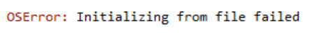

显示读取失败 若读取csv文件有中文报错编码错误，则加上engine='python’也可以，不需要加中文编码也会正确读取文件。

解决措施：  
把bankloan.csv文件转成utf8存储格式的csv文件bankloan_utf8.csv

Excel如何保存csv为utf-8格式  
https://www.cnblogs.com/zhengyyao/p/7481322.html

[figure not shown]

```python
#!/usr/bin/python
import pandas as pd
# -*- coding: utf-8 -*-       #Python UTF-8编码设置,读入中文字符
df = pd.read_csv(r"bankloan.csv",index_col=0,usecols=[0,1,2],nrows=5,engine='python')
df
```

| id | 年龄 | 教育 |
| --- | --- | --- |
| 1 | 41 | 3 |
| 2 | 27 | 1 |
| 3 | 40 | 1 |
| 4 | 41 | 1 |
| 5 | 24 | 2 |

## （二） CSV导出

在导出 CSV 的时候，要使用到的方法是 to_csv() ，和上面导出 Excel 实际上相差并不大，一样是要先设置文件路径，接下来可以设置索引、导出的列、分隔符号、编码格式、缺失值等等。  
DataFrame.to_csv(self, path_or_buf: Union[str, pathlib.Path, IO[~AnyStr], NoneType] = None, sep: str = ',', na_rep: str = '', float_format: Union[str, NoneType] = None, columns: Union[Sequence[Union[Hashable, NoneType]], NoneType] = None, header:  
Union[bool, List[str]] = True, index: bool = True, index_label: Union[bool, str, Sequence[Union[Hashable, NoneType]],  
NoneType] = None, mode: str = 'w', encoding: Union[str, NoneType] = None,  
compression: Union[str, Mapping[str, str], NoneType] = 'infer', quoting:  
Union[int, NoneType] = None, quotechar: str = '"', line_terminator: Union[str, NoneType] = None, chunksize:  
Union[int, NoneType] = None, date_format:  
Union[str, NoneType] = None, doublequote: bool = True, escapechar: Union[str, NoneType] = None,  
decimal: Union[str, NoneType] = '.') → Union[str, NoneType]

可以看到的是 to_csv() 比较 to_excel() 有着更多的参数，实际上，我们一些常用的参数并不多。

```python
import pandas as pd
#!/usr/bin/python   #告诉操作系统执行这个脚本的时候，调用/usr/bin下的python3解释器
# -*- coding: utf-8 -*-

df.to_csv(r"bankloan_out.csv", # 设置导出路径
          sep=',', # 设置分隔符号
          na_rep='0', # 缺失值处理
          columns=['年龄','教育'],  # 设置要导出的列
          encoding='gbk')  #如果没有encoding设置，会出现中文乱码
```

```python
import pandas as pd
#!/usr/bin/python   #告诉操作系统执行这个脚本的时候，调用/usr/bin下的python3解释器
# -*- coding: utf-8 -*-

df.to_csv(r"bankloan_out.csv", # 设置导出路径
          index=True,  # 设置索引显示
          sep=',', # 设置分隔符号
          na_rep='0', # 缺失值处理
          columns=['年龄','教育'],  # 设置要导出的列
         )
```

# 如果没有encoding设置，会出现中文乱码

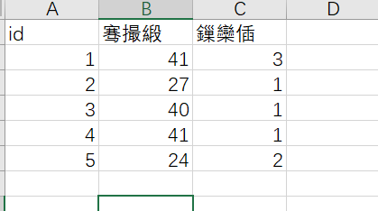

# 三、txt文件导入导出

## （一） txt文件导入

**文件导入(read_table)**

import pandas as pd  
df = pd.read_csv(‘text.txt’,sep=’\t’,encoding = ‘utf-8’)

# df = pd.read_table(‘text.txt’,sep=’\t’,encoding = ‘utf-8’) table同样可以

# 将txt或csv文件读取进来，sep = ‘\t’或sep=‘ ,’会自动识别空格，encoding = ‘utf-8’帮助识别中文

读文本文件格式的数据函数的注意事项：

```
1.读不同分隔符的文本文件，用参数sep

2.读无字段名（表头）的文本文件 ，用参数names

3.为文本文件制定索引，用index_col

4.跳行读取文本文件，用skiprows

5.数据太大时需要逐块读取文本数据用chunksize进行分块。
```

（二）将数据写成文本文件格式函数：to_csv

文件导出  
text_export = df.groupby(‘ab’).cd.count()  
text_export.to_csv(‘E:/text.csv’)

# 这样导出的文件会是储存在E盘，以text命名的CSV文件

https://www.cnblogs.com/manjianlei/p/11266313.html

```python
import pandas as pd
pd.read_table('bankloan1.txt',sep='|',nrows=5,encoding='gbk',engine='python')#使用'|'分割不同的列
```

|  | id\t年龄\t教育\t工龄\t地址\t收入\t负债率\t信用卡负债\t其他负债\t违约 |
| --- | --- |
| 0 | 1\t41\t3\t17\t12\t176\t9.3\t11.359392\t5.00860... |
| 1 | 2\t27\t1\t10\t6\t31\t17.3\t1.362202\t4.000798\t0 |
| 2 | 3\t40\t1\t15\t14\t55\t5.5\t0.856075\t2.168925\t0 |
| 3 | 4\t41\t1\t15\t14\t120\t2.9\t2.65872\t0.82128\t0 |
| 4 | 5\t24\t2\t2\t0\t28\t17.3\t1.787436\t3.056564\t1 |

```python
#以tab（制表符）为分隔符
data1=pd.read_table('bankloan1.txt',sep='\t',encoding='gbk',nrows=5,engine='python')
data1
```

|  | id | 年龄 | 教育 | 工龄 | 地址 | 收入 | 负债率 | 信用卡负债 | 其他负债 | 违约 |
| --- | --- | --- | --- | --- | --- | --- | --- | --- | --- | --- |
| 0 | 1 | 41 | 3 | 17 | 12 | 176 | 9.3 | 11.359392 | 5.008608 | 1 |
| 1 | 2 | 27 | 1 | 10 | 6 | 31 | 17.3 | 1.362202 | 4.000798 | 0 |
| 2 | 3 | 40 | 1 | 15 | 14 | 55 | 5.5 | 0.856075 | 2.168925 | 0 |
| 3 | 4 | 41 | 1 | 15 | 14 | 120 | 2.9 | 2.658720 | 0.821280 | 0 |
| 4 | 5 | 24 | 2 | 2 | 0 | 28 | 17.3 | 1.787436 | 3.056564 | 1 |

```python
import pandas as pd
data2=pd.read_table(r'bankloan1.txt',encoding='gbk',nrows=5,engine='python')
data2
```

|  | id | 年龄 | 教育 | 工龄 | 地址 | 收入 | 负债率 | 信用卡负债 | 其他负债 | 违约 |
| --- | --- | --- | --- | --- | --- | --- | --- | --- | --- | --- |
| 0 | 1 | 41 | 3 | 17 | 12 | 176 | 9.3 | 11.359392 | 5.008608 | 1 |
| 1 | 2 | 27 | 1 | 10 | 6 | 31 | 17.3 | 1.362202 | 4.000798 | 0 |
| 2 | 3 | 40 | 1 | 15 | 14 | 55 | 5.5 | 0.856075 | 2.168925 | 0 |
| 3 | 4 | 41 | 1 | 15 | 14 | 120 | 2.9 | 2.658720 | 0.821280 | 0 |
| 4 | 5 | 24 | 2 | 2 | 0 | 28 | 17.3 | 1.787436 | 3.056564 | 1 |

```python
#skiprows=[0,1,3]将bankloan数据对应的索引行0，1，3行跳过后读取其他行数据，不管首行是否作为表头，都是将表头作为第0行开始数
pd.read_table(r'bankloan1.txt',skiprows=[0,1,3],encoding='gbk',engine='python')
```

|  | 2 | 27 | 1 | 10 | 6 | 31 | 17.3 | 1.362202 | 4.000798 | 0 |
| --- | --- | --- | --- | --- | --- | --- | --- | --- | --- | --- |
| 0 | 4 | 41 | 1 | 15 | 14 | 120 | 2.9 | 2.658720 | 0.821280 | 0 |
| 1 | 5 | 24 | 2 | 2 | 0 | 28 | 17.3 | 1.787436 | 3.056564 | 1 |
| 2 | 6 | 41 | 2 | 5 | 5 | 25 | 10.2 | 0.392700 | 2.157300 | 0 |
| 3 | 7 | 39 | 1 | 20 | 9 | 67 | 30.6 | 3.833874 | 16.668126 | 0 |
| 4 | 8 | 43 | 1 | 12 | 11 | 38 | 3.6 | 0.128592 | 1.239408 | 0 |
| ... | ... | ... | ... | ... | ... | ... | ... | ... | ... | ... |
| 842 | 846 | 34 | 1 | 12 | 15 | 32 | 2.7 | 0.239328 | 0.624672 |  |
| 843 | 847 | 32 | 2 | 12 | 11 | 116 | 5.7 | 4.026708 | 2.585292 |  |
| 844 | 848 | 48 | 1 | 13 | 11 | 38 | 10.8 | 0.722304 | 3.381696 |  |
| 845 | 849 | 35 | 2 | 1 | 11 | 24 | 7.8 | 0.417456 | 1.454544 |  |
| 846 | 850 | 37 | 1 | 20 | 13 | 41 | 12.9 | 0.899130 | 4.389870 |  |

847 rows × 10 columns

skiprows=[0,1,3]的说明：

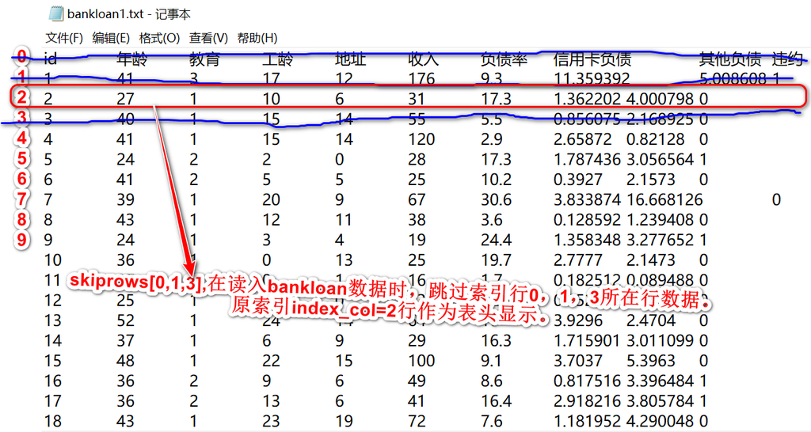